# Dataset Glossary (Column-wise) :

Customer ID - Unique identifier for each customer

Age - Age of the customer

Gender - Gender of the customer (Male/Female)

Item Purchased - The item purchased by the customer

Category - Category of the item purchased

Purchase Amount (USD) - The amount of the purchase in USD

Location - Location where the purchase was made

Size - Size of the purchased item

Color - Color of the purchased item

Season - Season during which the purchase was made

Review Rating - Rating given by the customer for the purchased item

Subscription Status - Indicates if the customer has a subscription (Yes/No)

Shipping Type - Type of shipping chosen by the customer

Discount Applied - Indicates if a discount was applied to the purchase (Yes/No)

Promo Code Used - Indicates if a promo code was used for the purchase (Yes/No)

Previous Purchases - The total count of transactions concluded by the customer at the store, excluding the ongoing transaction

Payment Method - Customer's most preferred payment method

Frequency of Purchases - Frequency at which the customer makes purchases (e.g., Weekly, Fortnightly, Monthly)

# Importing Libraries

```python
import pandas as pd
import seaborn as sns
import numpy as np
import matplotlib.pyplot as plt
```

# Loading the Dataset

```python
df = pd.read_csv("shopping_trends.csv")
df
```

|  | Customer ID | Age | Gender | Item Purchased | Category | Purchase Amount (USD) | Location | Size | Color | Season | Review Rating | Subscription Status | Shipping Type | Discount Applied | Promo Code Used | Previous Purchases | Payment Method | Frequency of Purchases |
| --- | --- | --- | --- | --- | --- | --- | --- | --- | --- | --- | --- | --- | --- | --- | --- | --- | --- | --- |
| 0 | 1 | 55 | Male | Blouse | Clothing | 53 | Kentucky | L | Gray | Winter | 3.1 | Yes | Express | Yes | Yes | 14 | Venmo | Fortnightly |
| 1 | 2 | 19 | Male | Sweater | Clothing | 64 | Maine | L | Maroon | Winter | 3.1 | Yes | Express | Yes | Yes | 2 | Cash | Fortnightly |
| 2 | 3 | 50 | Male | Jeans | Clothing | 73 | Massachusetts | S | Maroon | Spring | 3.1 | Yes | Free Shipping | Yes | Yes | 23 | Credit Card | Weekly |
| 3 | 4 | 21 | Male | Sandals | Footwear | 90 | Rhode Island | M | Maroon | Spring | 3.5 | Yes | Next Day Air | Yes | Yes | 49 | PayPal | Weekly |
| 4 | 5 | 45 | Male | Blouse | Clothing | 49 | Oregon | M | Turquoise | Spring | 2.7 | Yes | Free Shipping | Yes | Yes | 31 | PayPal | Annually |
| ... | ... | ... | ... | ... | ... | ... | ... | ... | ... | ... | ... | ... | ... | ... | ... | ... | ... | ... |
| 3895 | 3896 | 40 | Female | Hoodie | Clothing | 28 | Virginia | L | Turquoise | Summer | 4.2 | No | 2-Day Shipping | No | No | 32 | Venmo | Weekly |
| 3896 | 3897 | 52 | Female | Backpack | Accessories | 49 | Iowa | L | White | Spring | 4.5 | No | Store Pickup | No | No | 41 | Bank Transfer | Bi-Weekly |
| 3897 | 3898 | 46 | Female | Belt | Accessories | 33 | New Jersey | L | Green | Spring | 2.9 | No | Standard | No | No | 24 | Venmo | Quarterly |
| 3898 | 3899 | 44 | Female | Shoes | Footwear | 77 | Minnesota | S | Brown | Summer | 3.8 | No | Express | No | No | 24 | Venmo | Weekly |
| 3899 | 3900 | 52 | Female | Handbag | Accessories | 81 | California | M | Beige | Spring | 3.1 | No | Store Pickup | No | No | 33 | Venmo | Quarterly |

3900 rows × 18 columns

```python
df.head(6)
```

|  | Customer ID | Age | Gender | Item Purchased | Category | Purchase Amount (USD) | Location | Size | Color | Season | Review Rating | Subscription Status | Shipping Type | Discount Applied | Promo Code Used | Previous Purchases | Payment Method | Frequency of Purchases |
| --- | --- | --- | --- | --- | --- | --- | --- | --- | --- | --- | --- | --- | --- | --- | --- | --- | --- | --- |
| 0 | 1 | 55 | Male | Blouse | Clothing | 53 | Kentucky | L | Gray | Winter | 3.1 | Yes | Express | Yes | Yes | 14 | Venmo | Fortnightly |
| 1 | 2 | 19 | Male | Sweater | Clothing | 64 | Maine | L | Maroon | Winter | 3.1 | Yes | Express | Yes | Yes | 2 | Cash | Fortnightly |
| 2 | 3 | 50 | Male | Jeans | Clothing | 73 | Massachusetts | S | Maroon | Spring | 3.1 | Yes | Free Shipping | Yes | Yes | 23 | Credit Card | Weekly |
| 3 | 4 | 21 | Male | Sandals | Footwear | 90 | Rhode Island | M | Maroon | Spring | 3.5 | Yes | Next Day Air | Yes | Yes | 49 | PayPal | Weekly |
| 4 | 5 | 45 | Male | Blouse | Clothing | 49 | Oregon | M | Turquoise | Spring | 2.7 | Yes | Free Shipping | Yes | Yes | 31 | PayPal | Annually |
| 5 | 6 | 46 | Male | Sneakers | Footwear | 20 | Wyoming | M | White | Summer | 2.9 | Yes | Standard | Yes | Yes | 14 | Venmo | Weekly |

```python
df.tail(4)
```

|  | Customer ID | Age | Gender | Item Purchased | Category | Purchase Amount (USD) | Location | Size | Color | Season | Review Rating | Subscription Status | Shipping Type | Discount Applied | Promo Code Used | Previous Purchases | Payment Method | Frequency of Purchases |
| --- | --- | --- | --- | --- | --- | --- | --- | --- | --- | --- | --- | --- | --- | --- | --- | --- | --- | --- |
| 3896 | 3897 | 52 | Female | Backpack | Accessories | 49 | Iowa | L | White | Spring | 4.5 | No | Store Pickup | No | No | 41 | Bank Transfer | Bi-Weekly |
| 3897 | 3898 | 46 | Female | Belt | Accessories | 33 | New Jersey | L | Green | Spring | 2.9 | No | Standard | No | No | 24 | Venmo | Quarterly |
| 3898 | 3899 | 44 | Female | Shoes | Footwear | 77 | Minnesota | S | Brown | Summer | 3.8 | No | Express | No | No | 24 | Venmo | Weekly |
| 3899 | 3900 | 52 | Female | Handbag | Accessories | 81 | California | M | Beige | Spring | 3.1 | No | Store Pickup | No | No | 33 | Venmo | Quarterly |

# Shape of the Dataset

```python
df.shape
```

```
(3900, 18)
```

```python
df.dtypes
```

```
Customer ID                 int64
Age                         int64
Gender                     object
Item Purchased             object
Category                   object
Purchase Amount (USD)       int64
Location                   object
Size                       object
Color                      object
Season                     object
Review Rating             float64
Subscription Status        object
Shipping Type              object
Discount Applied           object
Promo Code Used            object
Previous Purchases          int64
Payment Method             object
Frequency of Purchases     object
dtype: object
```

# Columns in the Dataset

```python
df.columns
```

```
Index(['Customer ID', 'Age', 'Gender', 'Item Purchased', 'Category',
       'Purchase Amount (USD)', 'Location', 'Size', 'Color', 'Season',
       'Review Rating', 'Subscription Status', 'Shipping Type',
       'Discount Applied', 'Promo Code Used', 'Previous Purchases',
       'Payment Method', 'Frequency of Purchases'],
      dtype='object')
```

# Information about the Dataset

```python
df.info()
```

```
<class 'pandas.core.frame.DataFrame'>
RangeIndex: 3900 entries, 0 to 3899
Data columns (total 18 columns):
 #   Column                  Non-Null Count  Dtype
---  ------                  --------------  -----
 0   Customer ID             3900 non-null   int64
 1   Age                     3900 non-null   int64
 2   Gender                  3900 non-null   object
 3   Item Purchased          3900 non-null   object
 4   Category                3900 non-null   object
 5   Purchase Amount (USD)   3900 non-null   int64
 6   Location                3900 non-null   object
 7   Size                    3900 non-null   object
 8   Color                   3900 non-null   object
 9   Season                  3900 non-null   object
 10  Review Rating           3900 non-null   float64
 11  Subscription Status     3900 non-null   object
 12  Shipping Type           3900 non-null   object
 13  Discount Applied        3900 non-null   object
 14  Promo Code Used         3900 non-null   object
 15  Previous Purchases      3900 non-null   int64
 16  Payment Method          3900 non-null   object
 17  Frequency of Purchases  3900 non-null   object
dtypes: float64(1), int64(4), object(13)
memory usage: 548.6+ KB
```

```python
df.describe()
```

|  | Customer ID | Age | Purchase Amount (USD) | Review Rating | Previous Purchases |
| --- | --- | --- | --- | --- | --- |
| count | 3900.000000 | 3900.000000 | 3900.000000 | 3900.000000 | 3900.000000 |
| mean | 1950.500000 | 44.068462 | 59.764359 | 3.749949 | 25.351538 |
| std | 1125.977353 | 15.207589 | 23.685392 | 0.716223 | 14.447125 |
| min | 1.000000 | 18.000000 | 20.000000 | 2.500000 | 1.000000 |
| 25% | 975.750000 | 31.000000 | 39.000000 | 3.100000 | 13.000000 |
| 50% | 1950.500000 | 44.000000 | 60.000000 | 3.700000 | 25.000000 |
| 75% | 2925.250000 | 57.000000 | 81.000000 | 4.400000 | 38.000000 |
| max | 3900.000000 | 70.000000 | 100.000000 | 5.000000 | 50.000000 |

# Checking if there are any null values present in the dataset or not ?

```python
df.isnull().sum()
```

```
Customer ID               0
Age                       0
Gender                    0
Item Purchased            0
Category                  0
Purchase Amount (USD)     0
Location                  0
Size                      0
Color                     0
Season                    0
Review Rating             0
Subscription Status       0
Shipping Type             0
Discount Applied          0
Promo Code Used           0
Previous Purchases        0
Payment Method            0
Frequency of Purchases    0
dtype: int64
```

# Checking if there are any duplicate values present in the dataset or not ?

```python
df.duplicated().sum()
```

```
0
```

# Number of unique values of each column

```python
df.nunique()
```

```
Customer ID               3900
Age                         53
Gender                       2
Item Purchased              25
Category                     4
Purchase Amount (USD)       81
Location                    50
Size                         4
Color                       25
Season                       4
Review Rating               26
Subscription Status          2
Shipping Type                6
Discount Applied             2
Promo Code Used              2
Previous Purchases          50
Payment Method               6
Frequency of Purchases       7
dtype: int64
```

```python
df["Gender"].value_counts()
```

```
Male      2652
Female    1248
Name: Gender, dtype: int64
```

```python
df["Category"].value_counts()
```

```
Clothing       1737
Accessories    1240
Footwear        599
Outerwear       324
Name: Category, dtype: int64
```

```python
df['Item Purchased'].value_counts()
```

```
Blouse        171
Jewelry       171
Pants         171
Shirt         169
Dress         166
Sweater       164
Jacket        163
Belt          161
Sunglasses    161
Coat          161
Sandals       160
Socks         159
Skirt         158
Shorts        157
Scarf         157
Hat           154
Handbag       153
Hoodie        151
Shoes         150
T-shirt       147
Sneakers      145
Boots         144
Backpack      143
Gloves        140
Jeans         124
Name: Item Purchased, dtype: int64
```

# Average age of customers

```python
average_age = df["Age"].mean()
print("Average Age:", average_age)
```

```
Average Age: 44.06846153846154
```

# Most common item purchased

```python
most_common_item = df['Item Purchased'].mode()
print("Most Common Item Purchased:", most_common_item)
```

```
Most Common Item Purchased: 0     Blouse
1    Jewelry
2      Pants
dtype: object
```

# Total purchase amount for each category

```python
total_purchase_by_category = df.groupby('Category')['Purchase Amount (USD)'].sum()
print("Total Purchase Amount by Category:")
print(total_purchase_by_category)
```

```
Total Purchase Amount by Category:
Category
Accessories     74200
Clothing       104264
Footwear        36093
Outerwear       18524
Name: Purchase Amount (USD), dtype: int64
```

# Average review rating for male customers and female customers

```python
average_rating_male = df[df['Gender'] == 'Male']['Review Rating'].mean()
average_rating_female = df[df['Gender'] == 'Female']['Review Rating'].mean()
print("Average Review Rating for Male Customers:", average_rating_male)
print("Average Review Rating for Female Customers:", average_rating_female)
```

```
Average Review Rating for Male Customers: 3.753959276018097
Average Review Rating for Female Customers: 3.7414262820512842
```

# Most common payment method used by customers

```python
most_common_payment_method = df['Payment Method'].mode()[0]
print("Most Common Payment Method:", most_common_payment_method)
```

```
Most Common Payment Method: PayPal
```

# Median purchase amount (USD)

```python
median_purchase_amount = df['Purchase Amount (USD)'].median()
print("Median Purchase Amount (USD):", median_purchase_amount)
```

```
Median Purchase Amount (USD): 60.0
```

# How many customers have opted for the Subscription

```python
subscription_count = df[df['Subscription Status'] == 'Yes']['Customer ID'].count()
print("Number of Customers with Subscription: ", subscription_count)
```

```
Number of Customers with Subscription:  1053
```

# Average purchase amount for customers with a subscription status of 'Yes' and 'No'

```python
avg_purchase_subscription_yes = df[df['Subscription Status'] == 'Yes']['Purchase Amount (USD)'].mean()
avg_purchase_subscription_no = df[df['Subscription Status'] == 'No']['Purchase Amount (USD)'].mean()
print("Average Purchase Amount for Subscription 'Yes':", avg_purchase_subscription_yes)
print("Average Purchase Amount for Subscription 'No':", avg_purchase_subscription_no)
```

```
Average Purchase Amount for Subscription 'Yes': 59.49192782526116
Average Purchase Amount for Subscription 'No': 59.865121180189675
```

# Average age of males and females who purchased from each category

```python
pd.crosstab(df['Gender'], df['Category'], values=df['Age'],aggfunc=np.average)
```

| Category Gender | Accessories | Clothing | Footwear | Outerwear |
| --- | --- | --- | --- | --- |
| Female | 44.283163 | 43.620504 | 44.482412 | 44.128713 |
| Male | 44.196934 | 43.859441 | 44.422500 | 44.394619 |

# Number of items purchased from each category

```python
pd.crosstab(df['Category'],df['Item Purchased']).T
```

| Category Item Purchased | Accessories | Clothing | Footwear | Outerwear |
| --- | --- | --- | --- | --- |
| Backpack | 143 | 0 | 0 | 0 |
| Belt | 161 | 0 | 0 | 0 |
| Blouse | 0 | 171 | 0 | 0 |
| Boots | 0 | 0 | 144 | 0 |
| Coat | 0 | 0 | 0 | 161 |
| Dress | 0 | 166 | 0 | 0 |
| Gloves | 140 | 0 | 0 | 0 |
| Handbag | 153 | 0 | 0 | 0 |
| Hat | 154 | 0 | 0 | 0 |
| Hoodie | 0 | 151 | 0 | 0 |
| Jacket | 0 | 0 | 0 | 163 |
| Jeans | 0 | 124 | 0 | 0 |
| Jewelry | 171 | 0 | 0 | 0 |
| Pants | 0 | 171 | 0 | 0 |
| Sandals | 0 | 0 | 160 | 0 |
| Scarf | 157 | 0 | 0 | 0 |
| Shirt | 0 | 169 | 0 | 0 |
| Shoes | 0 | 0 | 150 | 0 |
| Shorts | 0 | 157 | 0 | 0 |
| Skirt | 0 | 158 | 0 | 0 |
| Sneakers | 0 | 0 | 145 | 0 |
| Socks | 0 | 159 | 0 | 0 |
| Sunglasses | 161 | 0 | 0 | 0 |
| Sweater | 0 | 164 | 0 | 0 |
| T-shirt | 0 | 147 | 0 | 0 |

# Maximum and minimum review rating

```python
max_review_rating = df['Review Rating'].max()
min_review_rating = df['Review Rating'].min()
print("Maximum Review Rating:", max_review_rating)
print("Minimum Review Rating:", min_review_rating)
```

```
Maximum Review Rating: 5.0
Minimum Review Rating: 2.5
```

```python
Category = df['Category'].unique()
Category
```

```
array(['Clothing', 'Footwear', 'Outerwear', 'Accessories'], dtype=object)
```

```python
df['Color'].value_counts().nlargest(5)
```

```
Olive     177
Yellow    174
Silver    173
Teal      172
Green     169
Name: Color, dtype: int64
```

```python
df.groupby('Location')['Purchase Amount (USD)'].mean().sort_values(ascending = False)
```

```
Location
Alaska            67.597222
Pennsylvania      66.567568
Arizona           66.553846
West Virginia     63.876543
Nevada            63.379310
Washington        63.328767
North Dakota      62.891566
Virginia          62.883117
Utah              62.577465
Michigan          62.095890
Tennessee         61.974026
New Mexico        61.901235
Rhode Island      61.444444
Texas             61.194805
Arkansas          61.113924
Illinois          61.054348
Mississippi       61.037500
Massachusetts     60.888889
Iowa              60.884058
North Carolina    60.794872
Wyoming           60.690141
South Dakota      60.514286
New York          60.425287
Ohio              60.376623
Montana           60.250000
Idaho             60.075269
Nebraska          59.448276
New Hampshire     59.422535
Alabama           59.112360
California        59.000000
Indiana           58.924051
Georgia           58.797468
South Carolina    58.407895
Oklahoma          58.346667
Missouri          57.913580
Hawaii            57.723077
Louisiana         57.714286
Oregon            57.337838
Vermont           57.176471
Maine             56.987013
New Jersey        56.746269
Minnesota         56.556818
Colorado          56.293333
Wisconsin         55.946667
Florida           55.852941
Maryland          55.755814
Kentucky          55.721519
Delaware          55.325581
Kansas            54.555556
Connecticut       54.179487
Name: Purchase Amount (USD), dtype: float64
```

```python
# we are cutting the age into some category and storing in the different column
df['Age_category'] = pd.cut(df['Age'], bins= [0,15, 18 , 30 , 50 , 70] , labels= ['child' , 'teen' , 'Young Adults' ,'Middle-Aged Adults'
                                                                                             , 'old'] )
```

```python
df.head(5)
```

|  | Customer ID | Age | Gender | Item Purchased | Category | Purchase Amount (USD) | Location | Size | Color | Season | Review Rating | Subscription Status | Shipping Type | Discount Applied | Promo Code Used | Previous Purchases | Payment Method | Frequency of Purchases | Age_category |
| --- | --- | --- | --- | --- | --- | --- | --- | --- | --- | --- | --- | --- | --- | --- | --- | --- | --- | --- | --- |
| 0 | 1 | 55 | Male | Blouse | Clothing | 53 | Kentucky | L | Gray | Winter | 3.1 | Yes | Express | Yes | Yes | 14 | Venmo | Fortnightly | old |
| 1 | 2 | 19 | Male | Sweater | Clothing | 64 | Maine | L | Maroon | Winter | 3.1 | Yes | Express | Yes | Yes | 2 | Cash | Fortnightly | Young Adults |
| 2 | 3 | 50 | Male | Jeans | Clothing | 73 | Massachusetts | S | Maroon | Spring | 3.1 | Yes | Free Shipping | Yes | Yes | 23 | Credit Card | Weekly | Middle-Aged Adults |
| 3 | 4 | 21 | Male | Sandals | Footwear | 90 | Rhode Island | M | Maroon | Spring | 3.5 | Yes | Next Day Air | Yes | Yes | 49 | PayPal | Weekly | Young Adults |
| 4 | 5 | 45 | Male | Blouse | Clothing | 49 | Oregon | M | Turquoise | Spring | 2.7 | Yes | Free Shipping | Yes | Yes | 31 | PayPal | Annually | Middle-Aged Adults |

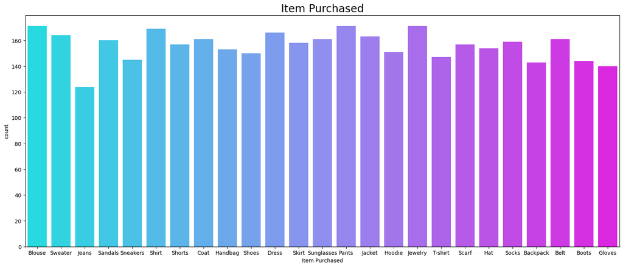

```python
plt.subplots(figsize=(20,8), dpi=100)
sns.countplot(data= df, x='Item Purchased',palette='cool')
plt.title("Item Purchased",fontsize=20)
plt.show()
```

The most sold Item are Blouse, Jewelry and Pants.

```python
CountOfCategory = df['Category'].value_counts()
CountOfCategory
```

```
Clothing       1737
Accessories    1240
Footwear        599
Outerwear       324
Name: Category, dtype: int64
```

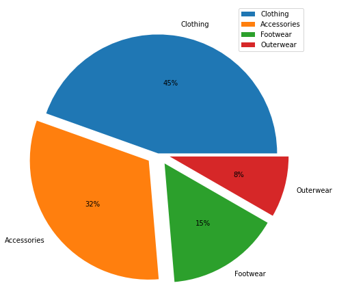

```python
plt.figure(figsize=(8,8))
plt.pie(CountOfCategory,labels=CountOfCategory.index,autopct='%0.0f%%',explode=(0,0.1,0.1,0.1))
plt.legend(CountOfCategory.index,loc =1)
plt.show()
```

Most types of Category of the item purchased are Clothing and Accessories.

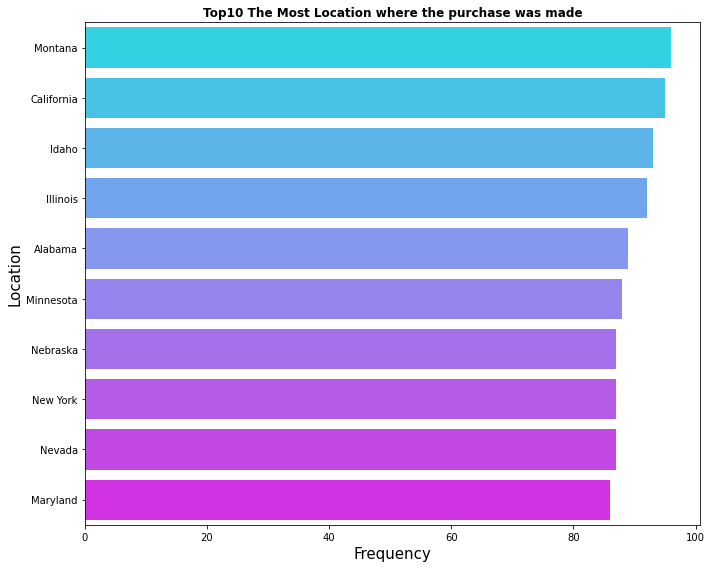

```python
top_10_Location = df.Location.value_counts().sort_values(ascending=False)[:10]
plt.figure(figsize=(10, 8))
sns.barplot(x=top_10_Location, y=top_10_Location.index,palette='cool',linewidth = 4)
plt.title('Top10 The Most Location where the purchase was made',loc='center',fontweight='bold',fontsize=12)
plt.xlabel('Frequency',fontsize=15)
plt.ylabel('Location',fontsize=15)
plt.tight_layout()
plt.show()
```

```python
size_count = df['Size'].value_counts()
size_count
```

```
M     1755
L     1053
S      663
XL     429
Name: Size, dtype: int64
```

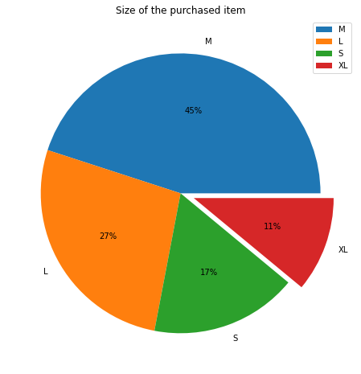

```python
plt.figure(figsize=(8,8))
plt.pie(size_count,labels=['M','L','S','XL'],autopct='%0.0f%%',explode=(0,0,0,0.1))
plt.legend( ['M','L','S','XL'],loc =1)
plt.title('Size of the purchased item')
plt.show()
```

The best-selling size is medium, followed by large

# Number of categories that are purchased in each season

```python
pd.crosstab(df['Season'],df['Category'])
```

| Category Season | Accessories | Clothing | Footwear | Outerwear |
| --- | --- | --- | --- | --- |
| Fall | 324 | 427 | 136 | 88 |
| Spring | 301 | 454 | 163 | 81 |
| Summer | 312 | 408 | 160 | 75 |
| Winter | 303 | 448 | 140 | 80 |

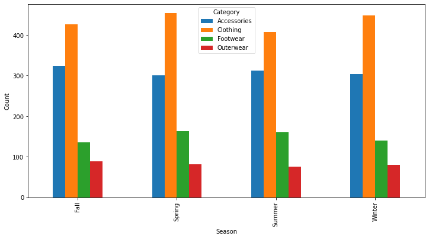

```python
pd.crosstab(df['Season'],df['Category']).plot(kind='bar',figsize=(12,6),ylabel='Count')
```

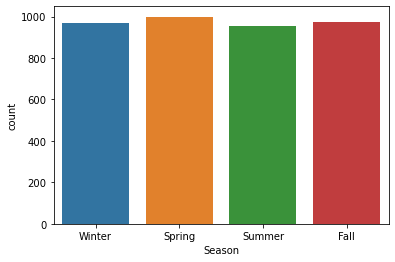

```python
sns.countplot(data= df, x='Season')
```

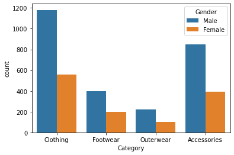

```python
sns.countplot(data= df, x='Category',hue='Gender')
```

```python
def summary(data):
    print(f'data shape : {df.shape}')
    sum=pd.DataFrame(df.dtypes,columns=['data type'])
    sum["Missing"]=df.isnull().sum()
    sum["%Missing"]=(df.isnull().sum()/len(df))*100
    sum['#unique']=df.nunique().values
    desc=pd.DataFrame(df.describe(include="all").transpose())
    sum['min']=desc['min'].values
    sum['max']=desc['max'].values
    sum['first value']=df.loc[0].values
    sum['second value']=df.loc[1].values
    sum['Third value']=df.loc[2].values

    return sum
```

```python
summary(df)
```

```
data shape : (3900, 19)
```

|  | data type | Missing | %Missing | #unique | min | max | first value | second value | Third value |
| --- | --- | --- | --- | --- | --- | --- | --- | --- | --- |
| Customer ID | int64 | 0 | 0.0 | 3900 | 1.0 | 3900.0 | 1 | 2 | 3 |
| Age | int64 | 0 | 0.0 | 53 | 18.0 | 70.0 | 55 | 19 | 50 |
| Gender | object | 0 | 0.0 | 2 | NaN | NaN | Male | Male | Male |
| Item Purchased | object | 0 | 0.0 | 25 | NaN | NaN | Blouse | Sweater | Jeans |
| Category | object | 0 | 0.0 | 4 | NaN | NaN | Clothing | Clothing | Clothing |
| Purchase Amount (USD) | int64 | 0 | 0.0 | 81 | 20.0 | 100.0 | 53 | 64 | 73 |
| Location | object | 0 | 0.0 | 50 | NaN | NaN | Kentucky | Maine | Massachusetts |
| Size | object | 0 | 0.0 | 4 | NaN | NaN | L | L | S |
| Color | object | 0 | 0.0 | 25 | NaN | NaN | Gray | Maroon | Maroon |
| Season | object | 0 | 0.0 | 4 | NaN | NaN | Winter | Winter | Spring |
| Review Rating | float64 | 0 | 0.0 | 26 | 2.5 | 5.0 | 3.1 | 3.1 | 3.1 |
| Subscription Status | object | 0 | 0.0 | 2 | NaN | NaN | Yes | Yes | Yes |
| Shipping Type | object | 0 | 0.0 | 6 | NaN | NaN | Express | Express | Free Shipping |
| Discount Applied | object | 0 | 0.0 | 2 | NaN | NaN | Yes | Yes | Yes |
| Promo Code Used | object | 0 | 0.0 | 2 | NaN | NaN | Yes | Yes | Yes |
| Previous Purchases | int64 | 0 | 0.0 | 50 | 1.0 | 50.0 | 14 | 2 | 23 |
| Payment Method | object | 0 | 0.0 | 6 | NaN | NaN | Venmo | Cash | Credit Card |
| Frequency of Purchases | object | 0 | 0.0 | 7 | NaN | NaN | Fortnightly | Fortnightly | Weekly |
| Age_category | category | 0 | 0.0 | 4 | NaN | NaN | old | Young Adults | Middle-Aged Adults |

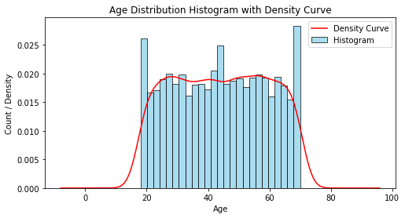

```python
plt.figure(figsize=(8, 4))
plt.hist(df['Age'],edgecolor = 'black',alpha=0.7,bins=25,color = 'skyblue',density=True)
df['Age'].plot(kind='kde', color = 'red')
plt.xlabel('Age')
plt.ylabel('Count / Density')
plt.title('Age Distribution Histogram with Density Curve')
plt.legend(['Density Curve', 'Histogram'])
plt.show()
```

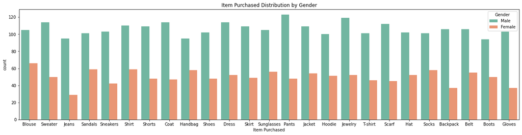

```python
plt.figure(figsize=(22,5))
sns.countplot(data=df,x='Item Purchased',hue='Gender',palette='Set2')
plt.title('Item Purchased Distribution by Gender')
plt.show()
```

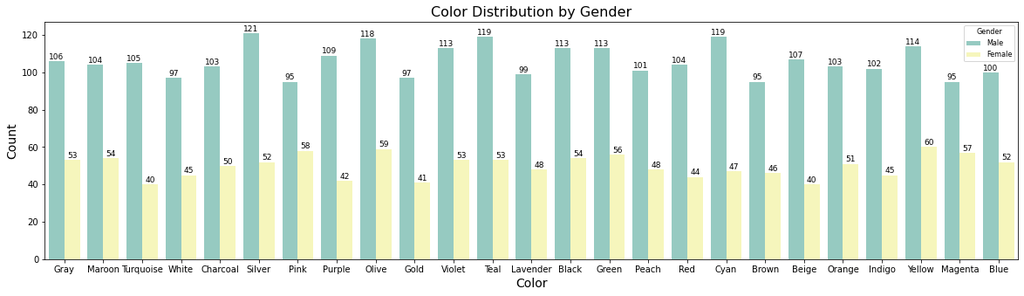

```python
plt.figure(figsize=(20,5))
ax=sns.countplot(data = df,x='Color',hue='Gender',palette='Set3')
for p in ax.patches:
    ax.annotate(f'{p.get_height()}', (p.get_x() + p.get_width() / 2., p.get_height()), ha='center', va='center', fontsize=9, color='black', xytext=(0, 5), textcoords='offset points')
plt.xlabel('Color', fontsize=14)
plt.ylabel('Count', fontsize=14)
plt.title('Color Distribution by Gender', fontsize=16)
plt.legend(title='Gender', fontsize=8, title_fontsize=8)
plt.show()
```

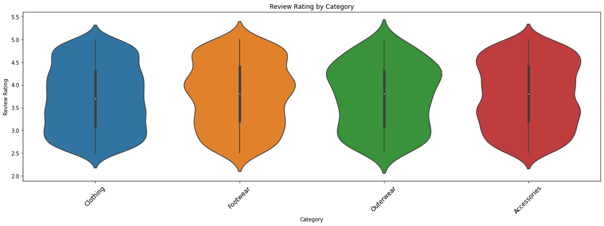

```python
plt.figure(figsize=(20, 6))
sns.violinplot(x='Category', y='Review Rating', data=df)
plt.title('Review Rating by Category')
plt.xlabel('Category')
plt.ylabel('Review Rating')
plt.xticks(rotation=45,fontsize=12)
plt.show()
```

```python
colors = ["#89CFF0", "#FF69B4", "#FFD700", "#7B68EE", "#FF4500",
          "#9370DB", "#32CD32", "#8A2BE2", "#FF6347", "#20B2AA",
          "#FF69B4", "#00CED1", "#FF7F50", "#7FFF00", "#DA70D6"]
```

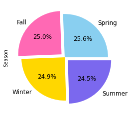

```python
count=df['Season'].value_counts()
count

count.plot(kind='pie',colors=colors,fontsize=12,explode=(0,0.1,0,0.1),autopct='%1.1f%%')
plt.show()
```

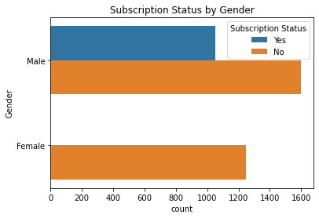

```python
sns.countplot(data=df,y='Gender',hue='Subscription Status')
plt.title('Subscription Status by Gender')
plt.show()
```

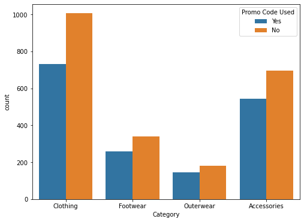

```python
plt.figure(figsize=(8,6))
sns.countplot(data=df,x='Category',hue='Promo Code Used')
```